# DIFseq User Guide

Fangda Song, Kevin Y. Yip and Yingying Wei

4 October 2023

#### Package

DIFseq 0.99.1

# 1 Introduction

A growing number of single-cell RNA-sequencing (scRNA-seq) studies collect cells from multiple conditions<sup>1–3</sup>. However, despite the urgent demands, statistical methods that can rigorously quantify the differences between scRNA-seq datasets are still lacking.

In the bulk RNA-sequencing era, solid statistical methods for calling differentially expressed (DE) genes have been the cornerstone of genomic research, with Limma<sup>4</sup>, DESeq<sup>5</sup> and edgeR<sup>6</sup> each serving tens of thousands of studies. Nevertheless, these classic methods are not applicable to scRNA-seq data. The main challenge is that although we know the biological condition of each cell—say, whether the cell was collected from a healthy individual or a patient—the cell type label of each cell is unknown. Therefore, for differential inference of scRNA-seq data, we have to simultaneously (a) infer the cell type label of each cell, (b) identify the cell-type-specific DE genes—genes that are DE between conditions in a given cell type and (c) quantify the compositional changes of cell types between conditions, that is, infer differential abundance (DA).

To deal with those problems, we develop DIFferential inference for scRNA-seq data (DIFseq). DIFseq is an interpretable Bayesian hierarchical model to simultaneously adjust batch effects, characterize the cell-type-specific size factors, the count data nature and the dropout events of scRNA-seq data, cluster cells into cell types and quantify the condition effects. Therefore, DIFseq is able to account for all of the uncertainties and rigorously quantify the condition effects on both cell-type-specific gene expression levels and cellular compositions for scRNA-seq data.

This guide provides step-by-step instructions for applying the DIFseq model to cluster cells and conducting differential expression and abundance analysis.

```r
library(DIFseq)
```

# 2 Data preparation

We first build a `DIFseq` object via the `CreateDIFseqObject` function. We extend the `SingleCellExperiment` class to store the parameter estimation results of the DIFseq model as the `DIFseq` class.

Like creating a `SingleCellExperiment` object, we require the raw count matrix, each row representing a gene and each column denoting a cell. In addition, we need to specify batch, condition and sample indices for all the cells via the `batch`, `condition` and `sample` arguments of the `CreateDIFseqObject` function, respectively. In particular, each of these three arguments needs a vector or factor with the same length as the total cell number.

Moreover, if the cell type number is known, we can directly set the cell type number via the `n.celltype` argument. Otherwise, we could select the optimal cell type number by some criterion, like Bayesian information criterion (BIC) or Akaike information criterion (AIC). We will explain more about selecting the optimal cell type number in Section Model Selection using BIC.

In the following, we take the stored `DIFseq` object—`DIFseq_obj`—as an example to explain the analyzing process by DIFseq. `DIFseq_obj` is a simulation dataset with 2 batches, 2 conditions and 20 samples. We totally measure 6000 cells and 100 genes in the simulated dataset.

First, we extract the raw count matrix from `DIFseq_obj` by the inherited method `assay` from the `SingleCellExperiment` class. All the other methods of the `SingleCellExperiment` class can also inherited by our `DIFseq` class. Second, we use a series of utility functions `BatchInd`, `CondInd` and `SampleInd` to obtain the batch, condition and sample indices from `DIFseq_obj`. Finally, we build a new `DIFseq` object by the raw count matrix and indices. Besides, we set the number of cell types as three.

```r
library(SingleCellExperiment)

count_data <- assay(DIFseq_obj, "counts")
batch_ind <- BatchInd(DIFseq_obj)
cond_ind <- CondInd(DIFseq_obj)
sample_ind <- SampleInd(DIFseq_obj)

Num_batch <- NumBatch(DIFseq_obj)
Num_cond <- NumCond(DIFseq_obj)
Num_celltype <- 3

Object <- CreateDIFseqObject(assay = list(counts = count_data),
                             batch = batch_ind, condition = cond_ind, sample = sample_ind,
                             n.celltype = Num_celltype)
```

# 3 Model Fitting

Once we have created the `DIFseq` object, we apply our proposed Monte-Carlo-Expectation-Maximaization (MCEM) algorithm to conduct statistical inference via the `DIFseq_MCEM` function.

We provide a series of utility functions to adjust the running parameters for the MCEM algorithm. In particular, we combine Monte-Carlo-Expectation steps and stochastic maximization steps in our proposed MCEM algorithm. In E steps, the `MCRep` function controls the number of replicates for the Monte-Carlo sampling. In the stochastic updating of M steps, the `MiniBatch` function allows us to control the mini-batch size of cells in the stochastic M step, while the `EarlyStop` function controls the times of observing non-decreasing log-likelihood to stop the MCEM algorithm. `CheckLike` controls how frequently we check the values of log-likelihood once. Please find more utility functions in the help file `?CheckLike`.

```r
wkdir <- "../DIFseq_test"
if(!dir.exists(wkdir)){
  dir.create(wkdir)
}

# The default number of replicates for MCE steps
MCRep(Object)
```

```
## [1] 10
```

```r
# The default number of early stop for the algorithm
EarlyStop(Object)
```

```
## [1] 10
```

```r
# Modify some parameters of the MCEM algorithm
MiniBatch(Object) <- 1000
CheckLike(Object) <- 3

Object <- DIFseq_MCEM(Object, count = "counts",
                      working_dir = "../DIFseq_test/")
```

```
##    conducting MCEM algorithm...
```

```
##    The MCEM algorithm takes: 3.979 mins
```

```
##    Correcting batch effects and cell size factor to obtain the corrected read count data...
```

```
## [1] "Finish the correction of 1000 cells..."
## [1] "Finish the correction of 2000 cells..."
## [1] "Finish the correction of 3000 cells..."
## [1] "Finish the correction of 4000 cells..."
## [1] "Finish the correction of 5000 cells..."
## [1] "Finish the correction of 6000 cells..."
```

After running the `DIFseq_MCEM` function, the state of `posterior inference` has changed from `FALSE` to `TRUE`. Moreover, it is easy to access the estimated cell type labels using the `CellTypes` function. The function returns a vector of the estimated cell type labels for each cell.

```r
Object
```

```
## class: DIFseq
## dim: 100 6000
## metadata(0):
## assays(3): counts imputed_count corrected_count
## rownames: NULL
## rowData names(0):
## colnames: NULL
## colData names(4): Batch Condition Pair Sample
## reducedDimNames(0):
## mainExpName: NULL
## altExpNames(0):
## batch, condition and sample number: 2, 2, 20
## posterior inference: TRUE
## differential expression: FALSE
## differential abundance: FALSE
```

```r
label_est <- CellTypes(Object)
table(label_est)
```

```
## label_est
##    1    2    3
## 2945 1544 1511
```

# 4 Visualize the esimated cell type effects, condition effects and batch effects

To check the estimated parameter values, we visualize the log-scale estimated cell type effects $\alpha_g+\beta_{gk},g=1,2,\cdots,G,k =1,2,3$ by a heatmap. Here, `Baseline` and `TypeEffects` are two functions extracting the baseline gene expression levels and the relative cell type effects from a `DIFseq` object. The `HeatmapEffects` function draws a heatmap for the obtained cell-type-effect matrix `Celltype_effects`. Here, the `ColSideColors` argument gives the colors of each column to annotate different cell types.

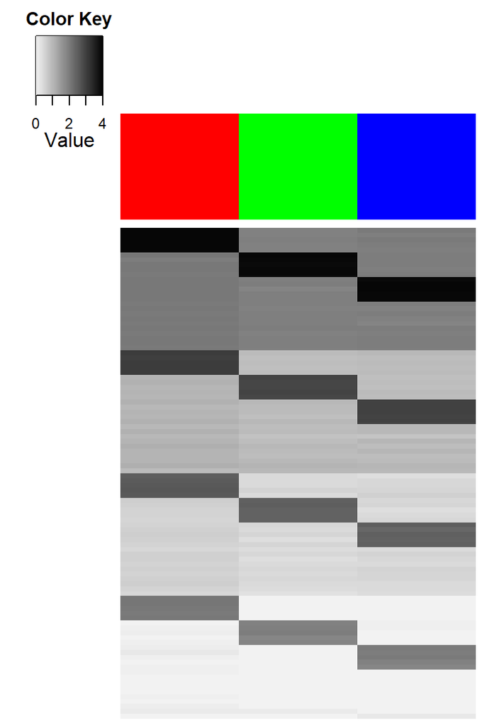

```r
# Extract the baseline effects and the relative cell type effects from the DIFseq object
Baseline_effects <- Baseline(Object)
Type_effects <- TypeEffects(Object)
Celltype_effects <- Baseline_effects + Type_effects

# Set the column-side colors and the break points for parameter values
Celltype_color <- rainbow(ncol(Celltype_effects))
break_celltype <- seq(0,4, length.out = 101)

heatmap_celltype <- HeatmapEffects(Celltype_effects, ColSideColors = Celltype_color, breaks = break_celltype)
```

Then, we visualize the condition effects for each pair of cell types and conditions. Here, `CondEffects` function extracts the estimated condition effects from the `DIFseq` object.

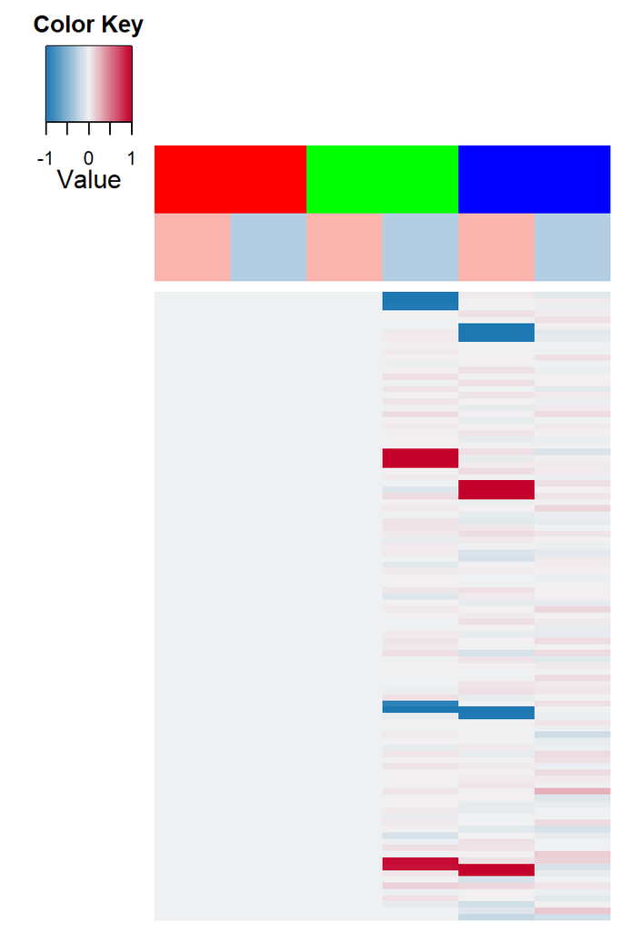

```r
# Extract the relative condition effects from the DIFseq object
Condition_effects <- CondEffects(Object)

# Set the column-side colors, the color keys and the break points for parameter values
Condition_color <- c("#fbb4ae","#b3cde3")

color_bar <- cbind(
  rep(Condition_color, Num_celltype),
  rep(Celltype_color, each = Num_cond))

break_celltype <- seq(-1,1, length.out = 101)
colorsChoice <- colorRampPalette(c("#1D78B2","#F2F2F2","#C4012D"))
celltype_key <- colorsChoice(100)

heatmap_condition <- HeatmapEffects(Condition_effects, ColSideColors = color_bar,
                      col = celltype_key, breaks = break_celltype)
```

Also, we visualize the batch effects for each batch. Here, `BatchEffects` function extracts batch effects from the `DIFseq` object.

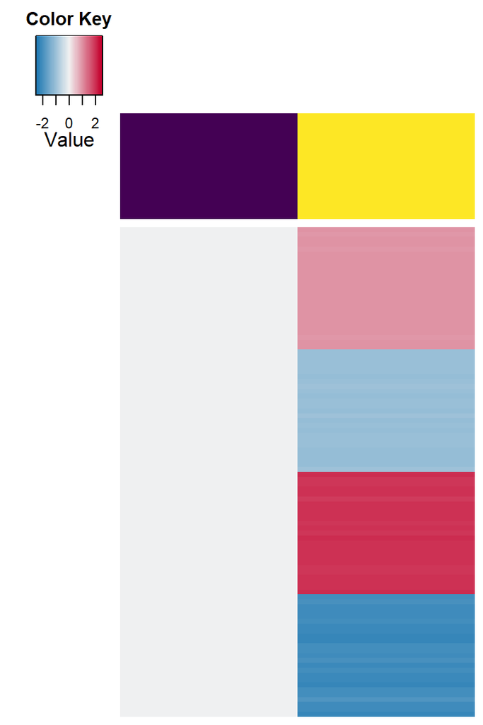

```r
# Extract the relative condition effects from the DIFseq object
Batch_effects <- BatchEffects(Object)

# Set the column-side colors, the color keys and the break points for parameter values
Batch_color <- c("#440154", "#FDE725")

break_celltype <- seq(-2.5,2.5, length.out = 101)
colorsChoice <- colorRampPalette(c("#1D78B2","#F2F2F2","#C4012D"))
celltype_key <- colorsChoice(100)

heatmap_batch <- HeatmapEffects(Batch_effects,
                      ColSideColors = Batch_color,
                      col = celltype_key, breaks = break_celltype)
```

# 5 Visualize corrected read counts

DIFseq is able to impute the missing data caused by dropout events and correct batch effects. As a result, DIFseq provides a version of corrected count data as if scRNA-seq data from different batches were collected from one single experiment. In other words, the corrected count data is free of unwanted batch effects but keeps biological variability across different cell types and conditions. Thus, the corrected count data facilitates the downstream analysis.

Here, we compare the raw count data that suffer from batch effects and dropout events, the inferred expression levels after imputing dropout events, and the corrected count data which remove the batch effects and impute the dropout events. These three types of count matrices are stored in the `assay` slot of the DIFseq object.

```r
assays(Object)
```

```
## List of length 3
## names(3): counts imputed_count corrected_count
```

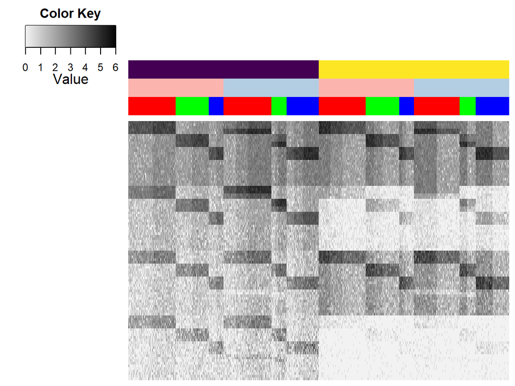

```r
raw_count <- assay(Object, "counts")
imputed_count <- assay(Object, "imputed_count")
corrected_count <- assay(Object, "corrected_count")

# Ordered by cell types
order_cells <- order(batch_ind, cond_ind, label_est)

# Set the column-side colors, the color keys and the break points for parameter values
color_count <- cbind(
  Celltype_color[label_est[order_cells]],
  Condition_color[cond_ind],
  Batch_color[batch_ind])


break_count <- seq(0,6, length.out = 101)

heatmap_rawcount <- HeatmapEffects(log1p(raw_count[,order_cells]), ColSideColors = color_count,
                                   breaks = break_count)
```

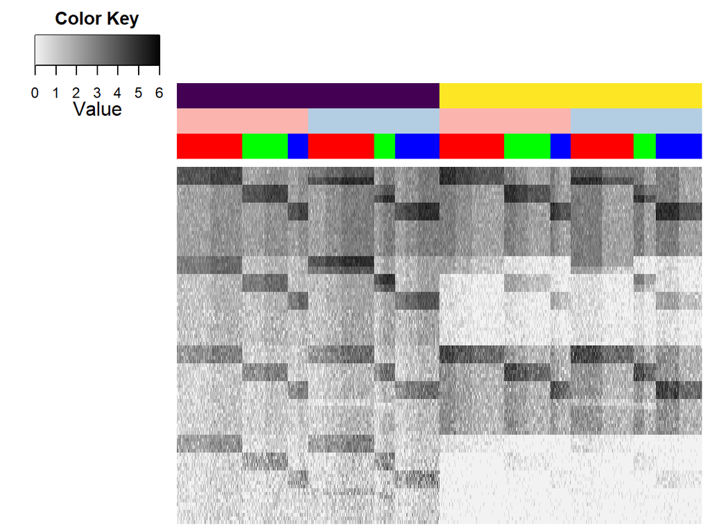

```r
heatmap_imputedcount <- HeatmapEffects(log1p(imputed_count[,order_cells]),
                                       ColSideColors = color_count,
                                   breaks = break_count)
```

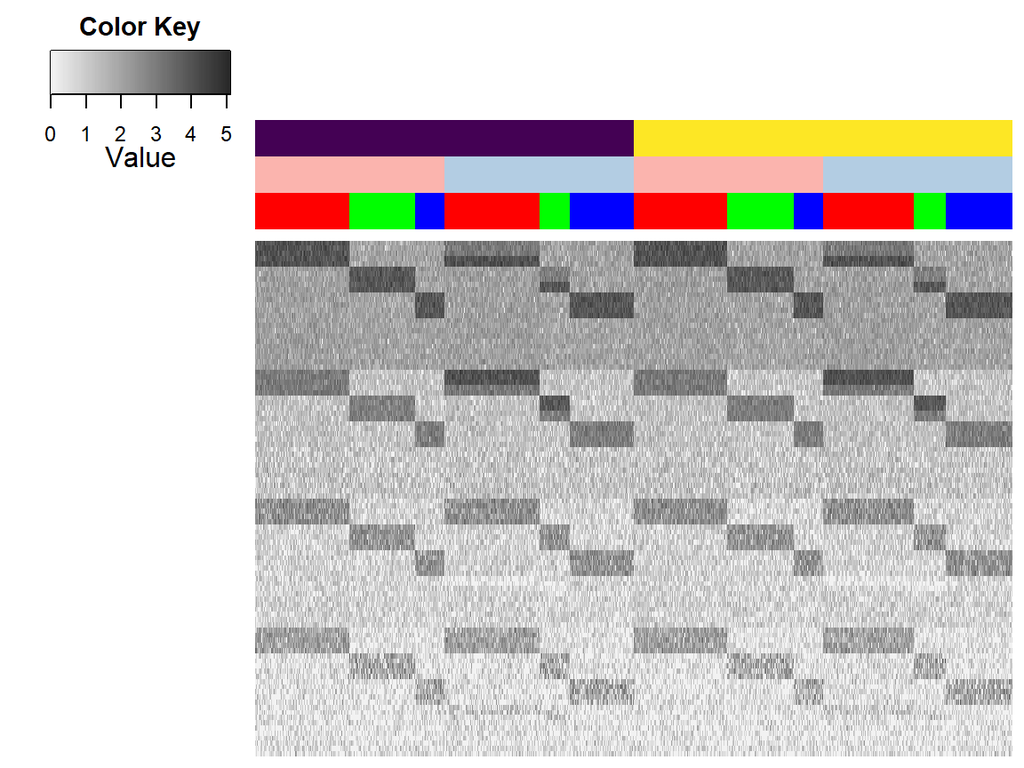

```r
heatmap_correctedcount <- HeatmapEffects(log1p(corrected_count[,order_cells]),
                                         ColSideColors = color_count,
                                   breaks = break_count)
```

The column color bar gives the batch, condition and cell-type-label information for each cell.